# R Notebook

seteo del directorio de trabajo actual, use su ruta a la carpeta del repositorio

Instalación y cargado de la librería necesaria para hacer el conteo de frecuencias de variable categórica

```r
install.packages('plyr')
library(plyr)
library(ggplot2)
```

## Cargado del csv principal para los análisis

```r
cultivos <- read.table("./documentos/cultivos_nacional_filtrado.csv", sep=",", header=TRUE)

head(cultivos)
```

|  | P_DEPTO | P_S6P46 | P_S6P47B | P_S6P59_UNIF | P_S6P60 | AREA_SEMBRADA | AREA_COSECHADA |
| --- | --- | --- | --- | --- | --- | --- | --- |
| 1 | 5 | 112201001 | 2012 | 3.277476 | 12 | 0.9541966 | 0.9541966 |
| 2 | 5 | 151001001 | 2013 | 16.022034 | 12 | 0.9541966 | 0.9541966 |
| 3 | 5 | 151001001 | 2012 | 14.948570 | 12 | 0.9541966 | 0.9541966 |
| 4 | 5 | 180201002 | 2007 | 3.852656 | 12 | 1.3533684 | 1.3533684 |
| 5 | 5 | 159201001 | 2013 | 18.642798 | 12 | 0.7151330 | 0.7151330 |
| 6 | 5 | 16100100101 | 1997 | 0.720000 | 12 | 0.7151330 | 0.7151330 |

```r
#
#selección de las columnas que nos interesan para este análisis inicial
cultivos_sub_top10 <- subset(cultivos, select=c("P_S6P46", "P_S6P60"))
cultivos_sub_top10 = data.frame(cultivos_sub_top10)

head(cultivos_sub_top10)
```

|  | P_S6P46 | P_S6P60 |
| --- | --- | --- |
| 1 | 112201001 | 12 |
| 2 | 151001001 | 12 |
| 3 | 151001001 | 12 |
| 4 | 180201002 | 12 |
| 5 | 159201001 | 12 |
| 6 | 16100100101 | 12 |

```r
#
# selección de todos los cultivos afectados

cultivos_afectados <- cultivos_sub_top10[cultivos_sub_top10$P_S6P60 != 12,]
head(cultivos_afectados)
```

|  | P_S6P46 | P_S6P60 |
| --- | --- | --- |
| 63 | 121903001 | 2 |
| 64 | 125402001 | 2 |
| 111 | 121903001 | 10 |
| 112 | 125402001 | 10 |
| 1615 | 125402001 | 2 |
| 1616 | 123401001 | 7 |

```r
NA
```

```r
#
# cuenta la cantidad de cultivos afectados para cada tipo de cultivo

freqs_cult_afect <- count(cultivos_afectados, "P_S6P46")
freqs_cult_afect <- freqs_cult_afect[order(-freqs_cult_afect$freq),]
freqs_cult_afect[0:10,]
```

|  | P_S6P46 | freq |
| --- | --- | --- |
| 49 | 131301001 | 13876 |
| 3 | 112201002 | 12499 |
| 113 | 159201001 | 11001 |
| 2 | 112201001 | 9694 |
| 109 | 151001001 | 7666 |
| 48 | 131201001 | 5818 |
| 140 | 191999056 | 3320 |
| 135 | 180201002 | 3290 |
| 124 | 164001001 | 3256 |
| 4 | 113202001 | 3056 |

## carga de csv para obtener equivalencias de código de cultivo a nombre del cultivo

```r
cultivos_code2name <- read.table("./documentos/equivalencias_cultivos_code.csv", sep=",", header=TRUE)

head(cultivos_code2name)
```

|  | P_S6P46 | nombre |
| --- | --- | --- |
| 1 | 196104035 | Abarco |
| 2 | 191999067 | Acacia Forrajera |
| 3 | 196104068 | Acacio |
| 4 | 196105051 | Aceite de marÃa |
| 5 | 121904001 | Acelga |
| 6 | 196104061 | Achapo |

```r
# ahora se hace el merge entre las 2 tablas para poder conocer los nombres del top 10
# de los cultivos más afectados

freqs_cult_afect_nombre = merge(x = cultivos_code2name, y=freqs_cult_afect, by = "P_S6P46", all=FALSE)
freqs_cult_afect_nombre = freqs_cult_afect_nombre[order(-freqs_cult_afect_nombre$freq),]
freqs_cult_afect_nombre[0:10,]
```

|  | P_S6P46 | nombre | freq |
| --- | --- | --- | --- |
| 49 | 131301001 | Platano | 13876 |
| 3 | 112201002 | Maíz Amarillo | 12499 |
| 113 | 159201001 | Yuca | 11001 |
| 2 | 112201001 | Maíz Blanco | 9694 |
| 109 | 151001001 | Papas | 7666 |
| 48 | 131201001 | Banano | 5818 |
| 140 | 191999056 | Fríjol | 3320 |
| 135 | 180201002 | Caña panelera | 3290 |
| 124 | 164001001 | Cacao grano | 3256 |
| 4 | 113202001 | Arroz verde | 3056 |

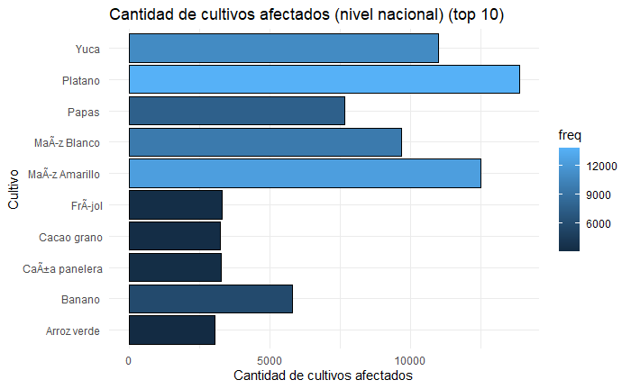

```r
# generación de la imagen del reporte, para solo verla en vez de guardarla como pdf
# comente la linea que invoca a la función pdf

#pdf(file = "./documentos/graficas_entrega_final/Cantidad de cultivos afectados (nivel nacional) (top 10).pdf")
p <- ggplot(data = freqs_cult_afect_nombre[0:10,], aes(x=nombre, y=freq, fill=freq)) + geom_bar(stat="identity", color="black") +
     coord_flip()
p <- p + labs(title="Cantidad de cultivos afectados (nivel nacional) (top 10)", x="Cultivo", y = "Cantidad de cultivos afectados")
p  + theme_minimal()
```

# Prueba de hipótesis para la diferencia de medias entre rendimientos de cultivos afectados y no afectados

```r
#
# selección de las columnas que nos interesan para este análisis inicial

cultivos_hipo <- subset(cultivos, select=c("P_S6P46", "P_S6P60", "P_S6P59_UNIF"))
cultivos_hipo = data.frame(cultivos_hipo)

head(cultivos_hipo)
```

|  | P_S6P46 | P_S6P60 | P_S6P59_UNIF |
| --- | --- | --- | --- |
| 1 | 112201001 | 12 | 3.277476 |
| 2 | 151001001 | 12 | 16.022034 |
| 3 | 151001001 | 12 | 14.948570 |
| 4 | 180201002 | 12 | 3.852656 |
| 5 | 159201001 | 12 | 18.642798 |
| 6 | 16100100101 | 12 | 0.720000 |

```r
NA
```

```r
# selección de los cultivos afectados y los no afectados en grupos distintos
# y borrado de los NA en la columna P_S6P59_UNIF -> 'rendimientos',
# también borra las filas que no tienen código de cultivo


cultivos_hipo_afect <- cultivos_hipo[(cultivos_hipo$P_S6P60 != 12),]
cultivos_hipo_afect <- cultivos_hipo_afect[complete.cases(cultivos_hipo_afect[,3]),]
cultivos_hipo_afect <- cultivos_hipo_afect[complete.cases(cultivos_hipo_afect[,1]),]

cultivos_hipo_no_afect <- cultivos_hipo[(cultivos_hipo$P_S6P60 == 12),]
cultivos_hipo_no_afect <- cultivos_hipo_no_afect[complete.cases(cultivos_hipo_no_afect[,3]),]
cultivos_hipo_no_afect <- cultivos_hipo_no_afect[complete.cases(cultivos_hipo_no_afect[,1]),]

head(cultivos_hipo_no_afect)
```

|  | P_S6P46 | P_S6P60 | P_S6P59_UNIF |
| --- | --- | --- | --- |
| 1 | 112201001 | 12 | 3.277476 |
| 2 | 151001001 | 12 | 16.022034 |
| 3 | 151001001 | 12 | 14.948570 |
| 4 | 180201002 | 12 | 3.852656 |
| 5 | 159201001 | 12 | 18.642798 |
| 6 | 16100100101 | 12 | 0.720000 |

```r
#
#obtención de los nombres correspondientes a los códigos de cultivo

cultivos_hipo_no_afect = merge(x = cultivos_code2name, y=cultivos_hipo_no_afect, by = "P_S6P46", all=FALSE)
cultivos_hipo_afect = merge(x = cultivos_code2name, y=cultivos_hipo_afect, by = "P_S6P46", all=FALSE)

head(cultivos_hipo_afect)
```

|  | P_S6P46 | nombre | P_S6P60 | P_S6P59_UNIF |
| --- | --- | --- | --- | --- |
| 1 | 111201001 | Trigo en grano | 7 | 3.432202 |
| 2 | 111201001 | Trigo en grano | 10 | 1.312838 |
| 3 | 111201001 | Trigo en grano | 5 | 3.277186 |
| 4 | 111201001 | Trigo en grano | 11 | 3.331678 |
| 5 | 111201001 | Trigo en grano | 7 | 3.317994 |
| 6 | 111201001 | Trigo en grano | 2 | 3.320472 |

```r
NA
```

```r
#toma únicamente los dátos del cultivo de plátano, tanto los datos de los cultivos afectados
#como los que no fueron afectados

platano_triste = cultivos_hipo_afect[cultivos_hipo_afect$nombre == "Platano ",]
platano_feliz = cultivos_hipo_no_afect[cultivos_hipo_no_afect$nombre == "Platano ",]

head(platano_feliz)
```

|  | P_S6P46 | nombre | P_S6P60 | P_S6P59_UNIF |
| --- | --- | --- | --- | --- |
| 578315 | 131301001 | Platano | 12 | 5.003673 |
| 578316 | 131301001 | Platano | 12 | 8.126980 |
| 578317 | 131301001 | Platano | 12 | 6.186887 |
| 578318 | 131301001 | Platano | 12 | 6.420560 |
| 578319 | 131301001 | Platano | 12 | 3.553809 |
| 578320 | 131301001 | Platano | 12 | 7.520362 |

```r
#obtiene la cantidad de cultivos
#para el grupo de plátanos afectados y no afectados

n1 = count(platano_feliz, "nombre")[,"freq"]
n2 = count(platano_triste, "nombre")[,"freq"]

print(c(n1,n2))
```

```
[1] 365863  13026
```

```r
#
#Calcula las medias de rendimiento del plátano no afectado y el afectado
#

mu_1 = mean(platano_feliz[,"P_S6P59_UNIF"])
mu_2 = mean(platano_triste[,"P_S6P59_UNIF"])

print(c(mu_1, mu_2))
```

```
[1] 5.458774 3.875260
```

```r
#
#Calcula las desviaciones estándar de rendimiento del plátano no afectado y el afectado
#

sd_1 = sd(platano_feliz[,"P_S6P59_UNIF"])
sd_2 = sd(platano_triste[,"P_S6P59_UNIF"])

print(c(sd_1, sd_2))
```

```
[1] 1.425433 1.697868
```

cálculo del estadístico de prueba (dado el tamaño de n se puede normalizar).

$\alpha = 0.05$

$h_o: \mu_1 - \mu_2 = 0$

$h_a: \mu_1 - \mu_2 \neq 0$

$RR: \{z: |z| > z_{\alpha/2} \}$

```r
std_err = sqrt( ((sd_1^2)/n1) + ((sd_2^2)/n2) )
std_err
```

```
[1] 0.01506192
```

```r
z_alfa_med = qnorm(1-0.025)
z = ( (mu_1 - mu_2) - (0))/std_err

print(c(z_alfa_med, z))
```

```
[1]   1.959964 105.133639
```

#### Intervalo de confianza

$\hat{\theta} \pm z_{\alpha/2} \cdot \sigma_{\hat{\theta}}$

```r
intervalo_conf = c(z - z_alfa_med *std_err, z + z_alfa_med *std_err)
print(intervalo_conf)
```

```
[1] 105.1041 105.1632
```

Al analizar que este intervalo de confianza está por mucho dentro del rango positivo vemos que, $\mu_1 > \mu_2$, es decir que un cultivo no afectado tiene mejores rendimientos

```r
p_valor = pnorm(z, lower.tail =FALSE)*2
print(p_valor)
```

```
[1] 0
```

### Con lo anterior rechazamos rotundamente que la diferencia de medias es cero, luego que un cultivo se vea afectado por algún factor ambiental incide en su rendimiento

## cálculo del error $\beta$

```r
diff_alt = 6*std_err
print(diff_alt)
```

```
[1] 0.09037151
```

```r
k = (z_alfa_med * std_err) + 0
print(k)
```

```
[1] 0.02952082
```

```r
pnorm( (k- 6*std_err)/std_err )
```

```
[1] 2.67215e-05
```

Se puede concluir que con total certeza hay una diferencia considerable en las medias, al todos los parametros probabilisticos que hallamos decir que hay que rechazar rotundamente H0. Ademas por la naturaleza de los resultados se puede decir que M1 es mayor a M2 con total certeza, por lo cual podemos decir que definitivamente hay una reduccion en el rendimiento de los cultivos de Platano cuando son afectados por algun agente externo negativo.

A partir de aqui haremos esta misma prueba de hipotesis pero para todas las especies de cultivos.

```r
cultivos_hipo_no_afect[1:10,]
```

|  | P_S6P46 | nombre | P_S6P60 | P_S6P59_UNIF |
| --- | --- | --- | --- | --- |
| 1 | 111201001 | Trigo en grano | 12 | 2.063049 |
| 2 | 111201001 | Trigo en grano | 12 | 3.438222 |
| 3 | 111201001 | Trigo en grano | 12 | 2.360736 |
| 4 | 111201001 | Trigo en grano | 12 | 2.412808 |
| 5 | 111201001 | Trigo en grano | 12 | 3.411425 |
| 6 | 111201001 | Trigo en grano | 12 | 2.408018 |
| 7 | 111201001 | Trigo en grano | 12 | 3.411425 |
| 8 | 111201001 | Trigo en grano | 12 | 3.411425 |
| 9 | 111201001 | Trigo en grano | 12 | 3.102294 |
| 10 | 111201001 | Trigo en grano | 12 | 3.411425 |

```r
#
#obtiene los tamaños poblacionales para los cultivos afectados y no afectados según el nombre del cultivo

n_afect = aggregate(cultivos_hipo_afect$P_S6P59_UNIF, list(cultivos_hipo_afect$nombre), length)
n_no_afect = aggregate(cultivos_hipo_no_afect$P_S6P59_UNIF, list(cultivos_hipo_no_afect$nombre), length)

n_afect = rename(n_afect, replace = c("x" = "n_triste"))
n_no_afect = rename(n_no_afect, replace = c("x" = "n_feliz"))

n_afect[1:10,]
```

|  | Group.1 | n_triste |
| --- | --- | --- |
| 1 | Ñame | 215 |
| 2 | Abarco | 2 |
| 3 | Acacio | 1 |
| 4 | Acelga | 25 |
| 5 | Achiote | 47 |
| 6 | Achiras | 25 |
| 7 | Agapanto (Flor de amor) | 1 |
| 8 | Aguacate | 419 |
| 9 | Ahuyama | 672 |
| 10 | Ajíes y pimientos | 362 |

```r
n_cults = merge(x = n_afect, y= n_no_afect, by = "Group.1", all=FALSE)
n_cults[1:10,]
```

|  | Group.1 | n_triste | n_feliz |
| --- | --- | --- | --- |
| 1 | Ñame | 215 | 43813 |
| 2 | Abarco | 2 | 16 |
| 3 | Acacio | 1 | 236 |
| 4 | Acelga | 25 | 859 |
| 5 | Achiote | 47 | 554 |
| 6 | Achiras | 25 | 16164 |
| 7 | Agapanto (Flor de amor) | 1 | 55 |
| 8 | Aguacate | 419 | 37596 |
| 9 | Ahuyama | 672 | 10627 |
| 10 | Ajíes y pimientos | 362 | 8008 |

```r
medias_afect = aggregate(cultivos_hipo_afect[,4], list(cultivos_hipo_afect$nombre), mean, na.rm=TRUE)
sd_afect = aggregate(cultivos_hipo_afect[,4], list(cultivos_hipo_afect$nombre), sd, na.rm=TRUE)

medias_afect = rename(medias_afect, replace = c("x" = "y_bar_triste"))
sd_afect = rename(sd_afect, replace = c("x" = "sd_triste"))

medias_afect[1:4,]
```

|  | Group.1 | y_bar_triste |
| --- | --- | --- |
| 1 | Ã‘ame | 35.06882 |
| 2 | Abarco | 8.40000 |
| 3 | Acacio | 6.60000 |
| 4 | Acelga | 10.60240 |

```r
sd_afect[1:4,]
```

|  | Group.1 | sd_triste |
| --- | --- | --- |
| 1 | Ã‘ame | 23.156036 |
| 2 | Abarco | 0.000000 |
| 3 | Acacio | NA |
| 4 | Acelga | 4.192021 |

```r
medias_no_afect = aggregate(cultivos_hipo_no_afect[,4], list(cultivos_hipo_no_afect$nombre), mean, na.rm=TRUE)
sd_no_afect = aggregate(cultivos_hipo_no_afect[,4], list(cultivos_hipo_no_afect$nombre), sd, na.rm=TRUE)

medias_no_afect = rename(medias_no_afect, replace = c("x" = "y_bar_feliz"))
sd_no_afect = rename(sd_no_afect, replace = c("x" = "sd_feliz"))


medias_no_afect[1:4,]
```

|  | Group.1 | y_bar_feliz |
| --- | --- | --- |
| 1 | Ñame | 2.766902 |
| 2 | Abarco | 8.024050 |
| 3 | Acacio | 6.382595 |
| 4 | Aceite de maría | 7.955736 |

```r
sd_no_afect[1:4,]
```

|  | Group.1 | sd_feliz |
| --- | --- | --- |
| 1 | Ñame | 2.7928239 |
| 2 | Abarco | 0.9363562 |
| 3 | Acacio | 2.0033063 |
| 4 | Aceite de maría | 1.1602724 |

```r
medias_rendimiento = merge(x = medias_afect, y= medias_no_afect, by = "Group.1", all=FALSE)
medias_rendimiento[1:4,]
```

|  | Group.1 | y_bar_triste | y_bar_feliz |
| --- | --- | --- | --- |
| 1 | Ã‘ame | 35.06882 | 2.766902 |
| 2 | Abarco | 8.40000 | 8.024050 |
| 3 | Acacio | 6.60000 | 6.382595 |
| 4 | Acelga | 10.60240 | 9.975504 |

```r
sd_rendimiento = merge(x = sd_afect, y= sd_no_afect, by = "Group.1", all=FALSE)
sd_rendimiento = sd_rendimiento[complete.cases(sd_rendimiento[,3]),]
sd_rendimiento[1:4,]
```

|  | Group.1 | sd_triste | sd_feliz |
| --- | --- | --- | --- |
| 1 | Ã‘ame | 23.156036 | 2.7928239 |
| 2 | Abarco | 0.000000 | 0.9363562 |
| 3 | Acacio | NA | 2.0033063 |
| 4 | Acelga | 4.192021 | 4.6103268 |

```r
sd_med_rend = merge(x = sd_rendimiento, y= medias_rendimiento, by = "Group.1", all=FALSE)
sd_med_rend[1:10,]
```

|  | Group.1 | sd_triste | sd_feliz | y_bar_triste | y_bar_feliz |
| --- | --- | --- | --- | --- | --- |
| 1 | Ñame | 23.156036 | 2.7928239 | 35.068819 | 2.766902 |
| 2 | Abarco | 0.000000 | 0.9363562 | 8.400000 | 8.024050 |
| 3 | Acacio | NA | 2.0033063 | 6.600000 | 6.382595 |
| 4 | Acelga | 4.192021 | 4.6103268 | 10.602398 | 9.975504 |
| 5 | Achiote | 0.000000 | 0.0000000 | 0.500000 | 0.500000 |
| 6 | Achiras | 2.245884 | 0.7400541 | 3.656089 | 1.451205 |
| 7 | Agapanto (Flor de amor) | NA | 9.8282767 | 7.142857 | 15.090371 |
| 8 | Aguacate | 1.733256 | 1.6430353 | 3.571413 | 6.026732 |
| 9 | Ahuyama | 2.242734 | 3.1312584 | 4.276226 | 5.819505 |
| 10 | Ajíes y pimientos | 2.536989 | 3.2811652 | 3.403022 | 5.360886 |

```r
sd_med_n =  merge(x = n_cults, y= sd_med_rend, by = "Group.1", all=FALSE)
sd_med_n[1:4,]
```

|  | Group.1 | n_triste | n_feliz | sd_triste | sd_feliz | y_bar_triste | y_bar_feliz |
| --- | --- | --- | --- | --- | --- | --- | --- |
| 1 | Ã‘ame | 215 | 43813 | 23.156036 | 2.7928239 | 35.06882 | 2.766902 |
| 2 | Abarco | 2 | 16 | 0.000000 | 0.9363562 | 8.40000 | 8.024050 |
| 3 | Acacio | 1 | 236 | NA | 2.0033063 | 6.60000 | 6.382595 |
| 4 | Acelga | 25 | 859 | 4.192021 | 4.6103268 | 10.60240 | 9.975504 |

```r
medias_diff = sd_med_n["y_bar_feliz"] - sd_med_n["y_bar_triste"]
sd_med_n["medias_diff"] = medias_diff
sd_med_n[1:4,]
```

|  | Group.1 | n_triste | n_feliz | sd_triste | sd_feliz | y_bar_triste | y_bar_feliz | medias_diff |
| --- | --- | --- | --- | --- | --- | --- | --- | --- |
| 1 | Ã‘ame | 215 | 43813 | 23.156036 | 2.7928239 | 35.06882 | 2.766902 | -32.3019170 |
| 2 | Abarco | 2 | 16 | 0.000000 | 0.9363562 | 8.40000 | 8.024050 | -0.3759496 |
| 3 | Acacio | 1 | 236 | NA | 2.0033063 | 6.60000 | 6.382595 | -0.2174049 |
| 4 | Acelga | 25 | 859 | 4.192021 | 4.6103268 | 10.60240 | 9.975504 | -0.6268936 |

```r
#borrado de los na que impiden calcular
sd_med_n = sd_med_n[complete.cases(sd_med_n[,4]),]

#selección de los cultivos que son normalizables
#dado que tienen n > 40
sd_med_n_norm = sd_med_n[sd_med_n$n_triste > 60,]
sd_med_n_norm = sd_med_n_norm[sd_med_n_norm$n_feliz > 60,]

sd_med_n_norm[1:4,]
```

|  | Group.1 | n_triste | n_feliz | sd_triste | sd_feliz | y_bar_triste | y_bar_feliz | medias_diff |
| --- | --- | --- | --- | --- | --- | --- | --- | --- |
| 1 | Ñame | 215 | 43813 | 23.156036 | 2.792824 | 35.068819 | 2.766902 | -32.301917 |
| 8 | Aguacate | 419 | 37596 | 1.733256 | 1.643035 | 3.571413 | 6.026732 | 2.455319 |
| 9 | Ahuyama | 672 | 10627 | 2.242734 | 3.131258 | 4.276226 | 5.819505 | 1.543279 |
| 10 | Ajíes y pimientos | 362 | 8008 | 2.536989 | 3.281165 | 3.403022 | 5.360886 | 1.957864 |

```r
sd_med_n_norm["std_err"] = sqrt((sd_med_n_norm$sd_feliz^2)/sd_med_n_norm$n_feliz +
                                (sd_med_n_norm$sd_triste^2)/sd_med_n_norm$n_triste)
```

```r
sd_med_n_norm["z"] = sd_med_n_norm$medias_diff/sd_med_n_norm$std_err
```

```r
#para un alfa de 0.05
alfa_med = 0.05
z_alfa = qnorm(alfa_med)

sd_med_n_norm["aceptar_ha"] = sd_med_n_norm$z < z_alfa
sd_med_n_norm["p_valor"] = pnorm((sd_med_n_norm$z), lower.tail = TRUE)


sd_med_n_norm["aceptar_ha(p_val)"] = sd_med_n_norm$p_valor < alfa_med
#aceptar_p
```

```r
z_final = sd_med_n_norm[,c("Group.1","aceptar_ha","aceptar_ha(p_val)", "z")]
z_final
```

|  | Group.1 | aceptar_ha | aceptar_ha(p_val) | z |
| --- | --- | --- | --- | --- |
| 1 | Ñame | TRUE | TRUE | -20.4535082 |
| 8 | Aguacate | FALSE | FALSE | 28.8528189 |
| 9 | Ahuyama | FALSE | FALSE | 16.8310095 |
| 10 | Ajíes y pimientos | FALSE | FALSE | 14.1576079 |
| 15 | Algodón | TRUE | TRUE | -4.8910274 |
| 23 | Arracacha | TRUE | TRUE | -4.3626098 |
| 25 | Arroz verde | FALSE | FALSE | 24.7337229 |
| 26 | Arveja verde | FALSE | FALSE | -0.4368230 |
| 35 | Banano | FALSE | FALSE | 81.5648690 |
| 36 | Batata | TRUE | TRUE | -6.2349252 |

[output cut: 54 more lines]

```r
#calcular el porcentaje de todos los cultivos para los cuales se cumple
#la hipótesis alternativa

total = length(sd_med_n_norm$Group.1)

sis = sd_med_n_norm[sd_med_n_norm$aceptar_ha == TRUE,]
sis = length(sis$Group.1)

ratio_ha_aceptada = sis*100/total
ratio_ha_aceptada
```

```
[1] 32.8125
```

A partir de aqui haremos la distribucion t con aquellos cultivos con n menos a 60. Los de mayor a 60 ya les hicimos la prueba z.

$t = \frac{y_1-y_2-0}{sp \sqrt{\frac{1}{n_1}+\frac{1}{n_2}}}$

$sp = \sqrt{\frac{(n_1-1)s_1^2+(n_2-1)s_2^2}{n_1+n_2-2}}$

```r
sd_med_n_tstudent = sd_med_n[sd_med_n$n_triste < 60,]
sd_med_n_tstudent = sd_med_n_tstudent[sd_med_n_tstudent$n_feliz  < 60,]

sd_med_n_tstudent[1:4,]
```

|  | Group.1 | n_triste | n_feliz | sd_triste | sd_feliz | y_bar_triste | y_bar_feliz | medias_diff |
| --- | --- | --- | --- | --- | --- | --- | --- | --- |
| 2 | Abarco | 2 | 16 | 0.0000000 | 0.9363562 | 8.4000000 | 8.024050 | -0.3759496 |
| 32 | Azucena | 12 | 23 | 0.0000000 | 0.4917578 | 10.8814582 | 11.113329 | 0.2318708 |
| 49 | CafÃ© Grano Verde - Chinchina | 3 | 58 | 0.2671822 | 0.0000000 | 0.4507884 | 0.720000 | 0.2692116 |
| 69 | Ceiba Tolua | 2 | 12 | 0.1135513 | 2.4350738 | 2.3458204 | 2.700639 | 0.3548190 |

```r
sd_med_n_tstudent["df"] = sd_med_n_tstudent$n_feliz + sd_med_n_tstudent$n_triste - 2

sd_med_n_tstudent["sp"] = sqrt(((sd_med_n_tstudent$n_feliz-1)*(sd_med_n_tstudent$sd_feliz)^2 + (sd_med_n_tstudent$n_triste-1)*(sd_med_n_tstudent$sd_triste)^2)/
                               (sd_med_n_tstudent$df))
```

Cálculo de la *t-student*:

```r
sd_med_n_tstudent["tstudent"] = (sd_med_n_tstudent$medias_diff)/(sd_med_n_tstudent$sp*(sqrt((1/sd_med_n_tstudent$n_feliz) +
                                                                                              (1/sd_med_n_tstudent$n_triste))))
```

Se calculan los *p-valores* y si según este y el valor del estadísitico de prueba, se debe o no rechazar la hipótesis nula.

```r
#para un alfa de 0.05
alfa_med_tstudent = 0.05
tstudent_alfa = qt(alfa_med_tstudent, df = sd_med_n_tstudent$df)

sd_med_n_tstudent["aceptar_ha"] = sd_med_n_tstudent$tstudent < tstudent_alfa
sd_med_n_tstudent["p_valor"] = pt((sd_med_n_tstudent$tstudent), df = sd_med_n_tstudent$df, lower.tail = TRUE)


sd_med_n_tstudent["aceptar_ha(p_val)"] = sd_med_n_tstudent$p_valor < alfa_med
```

```r
tstudent_final = sd_med_n_tstudent[,c("Group.1","aceptar_ha","aceptar_ha(p_val)", "tstudent")]
tstudent_final[1:4,]
```

|  | Group.1 | aceptar_ha | aceptar_ha(p_val) | tstudent |
| --- | --- | --- | --- | --- |
| 2 | Abarco | FALSE | FALSE | -0.5528937 |
| 32 | Azucena | FALSE | FALSE | 1.6216645 |
| 49 | CafÃ© Grano Verde - Chinchina | FALSE | FALSE | 9.2428746 |
| 69 | Ceiba Tolua | FALSE | FALSE | 0.1992451 |

guardar archivo de los datos como csv:

```r
#
write.csv(x = z_final, file = "./documentos/Tablas_PdH/Tabla_PdHMedias_Z.csv", row.names = TRUE)
write.csv(x = tstudent_final, file = "./documentos/Tablas_PdH/Tabla_PdHMedias_Tstudent.csv", row.names = TRUE)
```

*Ahora a partir de aqui graficamos las proporciones de la prueba de hipotesis*

```r
tstudent_final_porcentaje = tstudent_final[,c("Group.1","aceptar_ha")]
z_final_porcentaje = z_final[,c("Group.1","aceptar_ha")]

tabla_porcentaje = rbind(tstudent_final_porcentaje, z_final_porcentaje)
tabla_porcentaje
```

|  | Group.1 | aceptar_ha |
| --- | --- | --- |
| 2 | Abarco | FALSE |
| 32 | Azucena | FALSE |
| 49 | Café Grano Verde - Chinchina | FALSE |
| 69 | Ceiba Tolua | FALSE |
| 80 | Delphinium o pelícano | TRUE |
| 82 | Espinaca | FALSE |
| 130 | Nabo | TRUE |
| 140 | Paco | FALSE |
| 149 | Peine Mono | FALSE |
| 156 | Pinuela | FALSE |

[output cut: 64 more lines]

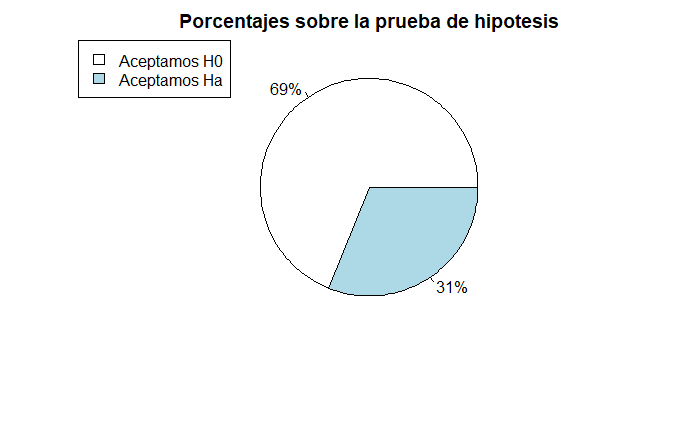

```r
porcentaje_h0 = round((51 * 100 / 74), 0)
porcentaje_ha = round((23 * 100 / 74), 0)
#pdf("./documentos/graficas_entrega_final/Piecharthipotesis.pdf")
pie(table(tabla_porcentaje$aceptar_ha), labels = paste0(c(porcentaje_h0, porcentaje_ha), "%"), main = ("Porcentajes sobre la prueba de hipotesis"))

legend("topleft", legend = c("Aceptamos H0", "Aceptamos Ha"),
       fill =  c("white", "lightblue"))
```